#### 1. Data Preparation

- The first step is to Load the data set from a CSV file (`nhis_2022.csv`). Remove rows where `ASTATFLG` isn’t 1 (indicating valid records).and Replace any invalid values in `MARSTCUR` (marital status) and other variables with `NA`. -Convert the `DIABETICEV` (diabetes variable) into a factor with two levels (`NoDisease` and `Disease`).
  - Remove rows with any missing values using `drop_na()`.
  - Finally, keep only relevant columns (`DIABETICEV`, `AGE`, `BMICALC`, `HRSLEEP`, `MOD10DMIN`, `CIGDAYMO`). The selected variables(predictors) AGE, BMICALC, HRSLEEP, MOD10DMIN, and CIGDAYMO were chosen based on both medical knowledge and statistical correlation with diabetes. AGE is a known risk factor, as the likelihood of developing diabetes increases with age. BMICALC (Body Mass Index) reflects body weight status; higher BMI is strongly associated with Type 2 diabetes. HRSLEEP represents sleep duration, which affects insulin sensitivity and metabolic health. MOD10DMIN measures physical activity, where lower exercise levels are linked to higher diabetes risk. CIGDAYMO, indicating cigarette use, is included because smoking contributes to insulin resistance and cardiovascular complications common in diabetics. Together, these variables capture key lifestyle and health factors known to influence diabetes risk.

```r
# Load required libraries
library(tidyverse)
library(caret)
library(e1071)
library(pROC)
```

```r
library(ggplot2)



# Load and clean data
nhis <- read_csv("C:/Users/Yeabs/Downloads/nhis_2022.csv") %>%
  # Keep only adults with valid response flags
  filter(ASTATFLG == 1) %>%

  # Recode values
  mutate(
    # Set invalid marital status codes to NA
    MARSTCUR = ifelse(MARSTCUR %in% 996:999, NA, MARSTCUR),

    # Recode diabetes variable
    DIABETICEV = factor(
      case_when(
        DIABETICEV == 2 ~ 1L,  # "Yes" → Disease
        DIABETICEV == 1 ~ 0L,  # "No" → NoDisease
        TRUE ~ NA_integer_
      ),
      levels = c(0, 1),
      labels = c("NoDisease", "Disease")
    ),

    # Set 996-999 as NA for predictors
    across(c(AGE, BMICALC, HRSLEEP, MOD10DMIN, CIGDAYMO),
           ~ ifelse(.x %in% 996:999, NA, as.numeric(.x)))
  ) %>%

  # Keep only married individuals for consistency
  filter(MARSTCUR == 1) %>%

  # Drop any remaining rows with NA
  drop_na() %>%

  # Select final modeling variables
  select(DIABETICEV, AGE, BMICALC, HRSLEEP, MOD10DMIN, CIGDAYMO)
# Verify factor structure
stopifnot(
  nlevels(nhis$DIABETICEV) == 2,
  all(c("NoDisease", "Disease") %in% levels(nhis$DIABETICEV))
)
```

#### 2. Train-Test Split & Scaling

- We split the data into a training set (70%) and a testing set (30%). `createDataPartition` ensures that the data is representative (stratified sampling) for the target variable (`DIABETICEV`). We apply feature scaling using `center` (mean centering) and `scale` (standardization) to the training and test data to make sure the variables are on the same scale.

```r
set.seed(123)
train_index <- createDataPartition(nhis$DIABETICEV, p = 0.7, list = FALSE)
train_data <- nhis[train_index, ]
test_data <- nhis[-train_index, ]

# Feature scaling
pre_proc <- preProcess(train_data, method = c("center", "scale"))
train_scaled <- predict(pre_proc, train_data)
test_scaled <- predict(pre_proc, test_data)
```

#### 3. Model Training

# Linear SVM with tuning

- Here, we calculate the class imbalance in the training data. The weight for the “Disease” class is adjusted based on its frequency in the dataset to make the model account for class imbalance.

To address the issue of class imbalance in the outcome variable DIABETICEV, class weighting was applied during model training. Specifically, the training set exhibited a much higher number of “NoDisease” cases compared to “Disease” cases. To compensate for this imbalance, weights were assigned inversely proportional to class frequency.

The weight for the minority class (“Disease”) was calculated as the ratio of “NoDisease” to “Disease” counts in the training data. This approach ensures that misclassifying a rare case (“Disease”) incurs a higher penalty, helping the SVM model pay more attention to the minority class. These weights were supplied to the svm() function using the class.weights parameter during model training.

```r
# Calculate class weights for imbalance
class_weights <- c(
  "Disease" = sum(train_scaled$DIABETICEV == "NoDisease")/nrow(train_scaled),
  "NoDisease" = sum(train_scaled$DIABETICEV == "Disease")/nrow(train_scaled)
)

# Linear SVM with tuning
set.seed(123)
tune_linear <- tune(
  svm,
  DIABETICEV ~ .,
  data = train_scaled,
  kernel = "linear",
  ranges = list(cost = c(0.01, 0.1, 1, 10, 100)),
  class.weights = class_weights,
  probability = TRUE
)

best_linear <- tune_linear$best.model
```

```r
summary(tune_linear)
```

```
##
## Parameter tuning of 'svm':
##
## - sampling method: 10-fold cross validation
##
## - best parameters:
##  cost
##    10
##
## - best performance: 0.3539744
##
## - Detailed performance results:
##    cost     error dispersion
## 1 1e-02 0.3666547 0.01922219
## 2 1e-01 0.3562437 0.01603154
## 3 1e+00 0.3546419 0.01608674
## 4 1e+01 0.3539744 0.01585588
## 5 1e+02 0.3539744 0.01585588
```

To optimize the performance of the linear SVM classifier, hyperparameter tuning was conducted using 10-fold cross-validation. The key parameter explored was the cost (C), which controls the trade-off between achieving a low training error and a low testing error (i.e., regularization strength).

A grid search was performed over the following cost values: 0.01, 0.1, 1, 10, 100. For each value, the model was evaluated using 10-fold cross-validation, and the average classification error was recorded.

# Radial SVM with tuning

```r
set.seed(123)
tune_radial <- tune(
  svm,
  DIABETICEV ~ .,
  data = train_scaled,
  kernel = "radial",
  ranges = list(
    cost = c(0.1, 1, 10),
    gamma = c(0.01, 0.1, 0.5)
  ),
  tunecontrol = tune.control(cross = 3),
  class.weights = class_weights,
  probability = TRUE
)

best_radial <- tune_radial$best.model
```

```r
summary(tune_radial)
```

```
##
## Parameter tuning of 'svm':
##
## - sampling method: 3-fold cross validation
##
## - best parameters:
##  cost gamma
##    10   0.5
##
## - best performance: 0.3493071
##
## - Detailed performance results:
##   cost gamma     error dispersion
## 1  0.1  0.01 0.3878782 0.02793981
## 2  1.0  0.01 0.3575815 0.01523804
## 3 10.0  0.01 0.3510414 0.01690580
## 4  0.1  0.10 0.3509079 0.01789161
## 5  1.0  0.10 0.3623867 0.02444168
## 6 10.0  0.10 0.3619862 0.01102162
## 7  0.1  0.50 0.3495721 0.02672652
## 8  1.0  0.50 0.3494403 0.02240575
## 9 10.0  0.50 0.3493071 0.02280972
```

This output shows the results of parameter tuning for the Radial SVM model using 3-fold cross-validation. The best performance was achieved with a **cost of 10** and **gamma of 0.5**, yielding an error rate of **0.3493071**.

The table lists the different combinations of **cost** and **gamma** values tested, along with their corresponding error rates and dispersion. The performance improves or worsens depending on the values of these parameters, with the best performance coming from the parameters `cost = 10` and `gamma = 0.5`.

# Polynomial SVM with tuning

```r
set.seed(123)
tune_poly <- tune(
  svm,
  DIABETICEV ~ .,
  data = train_scaled,
  kernel = "polynomial",
  ranges = list(
    cost = c(0.1, 1),
    degree = c(2, 3)
  ),
  tunecontrol = tune.control(cross = 3),
  class.weights = class_weights,
  probability = TRUE
)

best_poly <- tune_poly$best.model
```

```r
summary(tune_poly)
```

```
##
## Parameter tuning of 'svm':
##
## - sampling method: 3-fold cross validation
##
## - best parameters:
##  cost degree
##   0.1      2
##
## - best performance: 0.2018047
##
## - Detailed performance results:
##   cost degree     error dispersion
## 1  0.1      2 0.2018047 0.06862534
## 2  1.0      2 0.2778786 0.11684813
## 3  0.1      3 0.2090215 0.01165586
## 4  1.0      3 0.2127594 0.01223724
```

#### 4. Model Evaluation

```r
eval_model <- function(model, test_data) {
  pred <- predict(model, test_data)
  prob <- attr(predict(model, test_data, probability = TRUE), "probabilities")[, "Disease"]

  roc_obj <- roc(test_data$DIABETICEV, prob, quiet = TRUE)

  list(
    confusion = confusionMatrix(pred, test_data$DIABETICEV, positive = "Disease"),
    roc = roc_obj,
    auc = auc(roc_obj)
  )
}

results <- list(
  Linear = eval_model(best_linear, test_scaled),
  Radial = eval_model(best_radial, test_scaled),
  Polynomial = eval_model(best_poly, test_scaled)
)
```

#### 5. Visualization

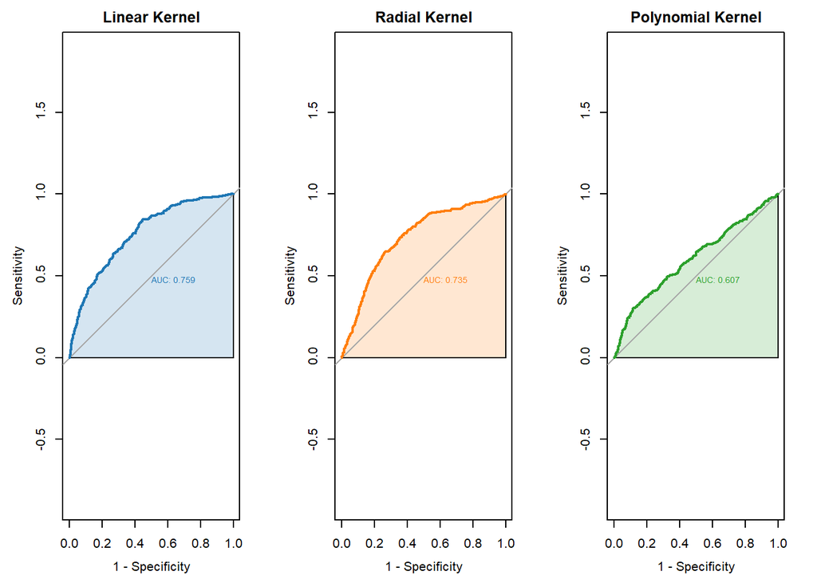

```r
# ROC Curves
par(mfrow = c(1, 3), mar = c(4, 4, 2, 1))
plot(results$Linear$roc, main = "Linear Kernel", col = "#1F77B4", legacy.axes = TRUE,
     auc.polygon = TRUE, print.auc = TRUE, auc.polygon.col = "#1F77B430")
plot(results$Radial$roc, main = "Radial Kernel", col = "#FF7F0E", legacy.axes = TRUE,
     auc.polygon = TRUE, print.auc = TRUE, auc.polygon.col = "#FF7F0E30")
plot(results$Polynomial$roc, main = "Polynomial Kernel", col = "#2CA02C", legacy.axes = TRUE,
     auc.polygon = TRUE, print.auc = TRUE, auc.polygon.col = "#2CA02C30")
```

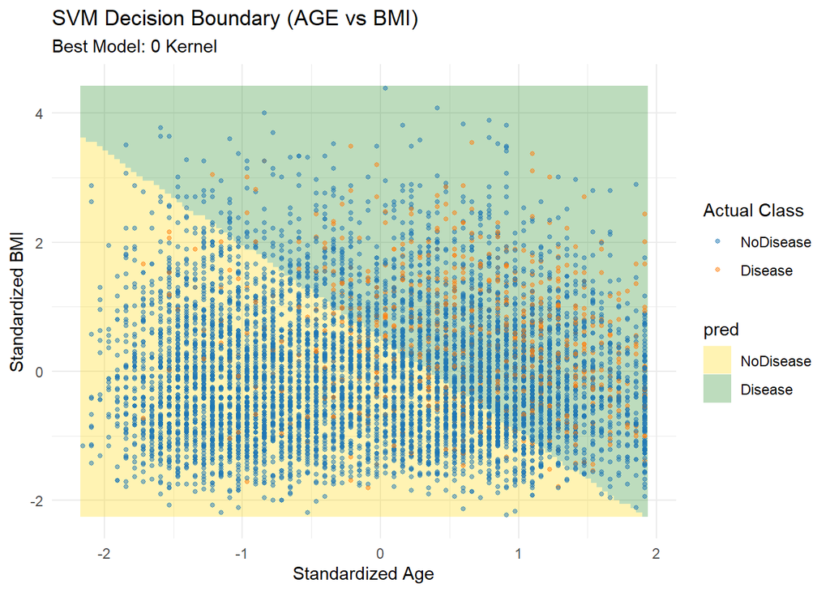

```r
# Decision Boundary Plot (using best model)
if (results$Linear$auc >= max(c(results$Linear$auc, results$Radial$auc, results$Polynomial$auc))) {
  best_model <- best_linear
} else if (results$Radial$auc >= results$Polynomial$auc) {
  best_model <- best_radial
} else {
  best_model <- best_poly
}

# Create grid for visualization
grid_data <- expand.grid(
  AGE = seq(min(train_scaled$AGE), max(train_scaled$AGE), length.out = 100),
  BMICALC = seq(min(train_scaled$BMICALC), max(train_scaled$BMICALC), length.out = 100),
  HRSLEEP = mean(train_scaled$HRSLEEP),
  MOD10DMIN = mean(train_scaled$MOD10DMIN),
  CIGDAYMO = mean(train_scaled$CIGDAYMO)
)

grid_data$pred <- predict(best_model, newdata = grid_data)

ggplot(grid_data, aes(AGE, BMICALC)) +
  geom_tile(aes(fill = pred), alpha = 0.3) +
  geom_point(data = train_scaled, aes(color = DIABETICEV), size = 1, alpha = 0.5) +
  scale_fill_manual(values = c("#FFD700", "#228B22")) +
  scale_color_manual(values = c("#1F77B4", "#FF7F0E")) +
  labs(
    title = "SVM Decision Boundary (AGE vs BMI)",
    subtitle = paste("Best Model:", ifelse(exists("best_model"), best_model$kernel, "Linear"), "Kernel"),
    x = "Standardized Age",
    y = "Standardized BMI",
    color = "Actual Class"
  ) +
  theme_minimal()
```

#### 6. Final Results

```r
cat("Best Linear SVM Parameters:\n")
```

```
## Best Linear SVM Parameters:
```

```r
print(tune_linear$best.parameters)
```

```
##   cost
## 4   10
```

```r
cat("\nBest Radial SVM Parameters:\n")
```

```
##
## Best Radial SVM Parameters:
```

```r
print(tune_radial$best.parameters)
```

```
##   cost gamma
## 9   10   0.5
```

```r
cat("\nBest Polynomial SVM Parameters:\n")
```

```
##
## Best Polynomial SVM Parameters:
```

```r
print(tune_poly$best.parameters)
```

```
##   cost degree
## 1  0.1      2
```

```r
performance_table <- data.frame(
  Model = c("Linear", "Radial", "Polynomial"),
  AUC = round(c(results$Linear$auc, results$Radial$auc, results$Polynomial$auc), 3),
  Sensitivity = round(c(results$Linear$confusion$byClass["Sensitivity"],
                       results$Radial$confusion$byClass["Sensitivity"],
                       results$Polynomial$confusion$byClass["Sensitivity"]), 3),
  Specificity = round(c(results$Linear$confusion$byClass["Specificity"],
                       results$Radial$confusion$byClass["Specificity"],
                       results$Polynomial$confusion$byClass["Specificity"]), 3),
  Accuracy = round(c(results$Linear$confusion$overall["Accuracy"],
                    results$Radial$confusion$overall["Accuracy"],
                    results$Polynomial$confusion$overall["Accuracy"]), 3)
)

print(performance_table)
```

```
##        Model   AUC Sensitivity Specificity Accuracy
## 1     Linear 0.759       0.756       0.616    0.629
## 2     Radial 0.735       0.749       0.631    0.643
## 3 Polynomial 0.607       0.305       0.884    0.827
```

Linear and Radial kernels perform similarly well (AUC ~0.75), with balanced sensitivity/specificity. Polynomial kernel has poor sensitivity (0.305) but high specificity (0.884), suggesting bias toward the negative class.